# Chapter 2: regression and model validation

*Describe the work you have done this week and summarize your learning.*

- Describe your work and results clearly.
- Assume the reader has an introductory course level understanding of writing and reading R code as well as statistical methods.
- Assume the reader has no previous knowledge of your data or the more advanced methods you are using.

```r
date()
```

```
## [1] "Thu Nov  5 21:06:42 2020"
```

## First some notes from the DataCamp exercises

the actual analysis exercise is further down

We can use a character vector to hold variable names, but then we need to use all_of() inside of select()

```r
vars <- c("var1", "var2", "var3")
analysis <- select(df, all_of(vars))
```

The syntax for renaming variables is rename(df, newName = oldName) no quotes

```r
rename(learning2014, dEEp = deep)
```

- filter() is like subset()
- geom_smooth() is used to add regression lines to plots
- pairs() a quick graphical comparison of all possible variable pairs in a data frame
- ggpairs() is same as pairs() but more advanced
  - with the ‘upper’ and ‘lower’ parameters it can be useful to use wrap()

## A couple of notes from the MABS4IODS book

On interpreting the p-value:

> The probability of obtaining the observed data (or data that represent a more extreme departure from the null hypothesis) if the null hypothesis is true.

and

> p-values should not be taken too seriously; confidence intervals are often more informative

Terminology:

response variable = intercept + (slope * explanatory var) + error

## More notes from the DataCamp exercises

### Video: Linear regression

Residuals: the difference between values predicted by the model and the actual values of the response variable *y*. The model is found by minimizing the sum of the squared residuals (distances of the data points from the regression line)

Meaning of the output of summary() * coefficients: estimates of the model parameters  
* intercept estimate: alpha of model * variable estimate: beta or slope of model * t-value and p-value testing the null hypothesis that the slope is 0 (no relationship between variables) * low p-value: we can conclude that there *IS* a relationship between the variables

Regression model object is created with lm() and it can also be multivariable (x1, x2, x3 …)  
Conveniently passing the object to plot() gives diagnostic plots

```r
my_lm <- lm(y ~ x1 + x2 + x3 ..., data = df)
plot(my_lm)
```

### Video: Model validation

The assumption of the model must be confirmed to be true before it should be trusted. Considering the residuals / errors, this means that (number 3 and 4 are essentially the same thing?): 1) errors are normally distributed 2) errors are not correlated 3) errors have constant variance 4) error size does not depend on explanatory variable

So how to examine this?  
* Normal distribution of residuals: the QQ-plot * Residuals are normally distributed if they fall on the line of the plot * Constant variance of errors = error size does not depend on explanatory variable * Plot residuals vs model predictions/fitted values * There should not be any kind of pattern * Leverage means how much impact a single observation has on the model * Plot residuals vs leverage and you will see which observations have an unusually high impact

The lm-object we created can be used to predict using and existing model: giving new values for the explanatory variable, we can predict the dependent variable

```r
predict(existing_model, newdata = df)
```

## And here goes the analysis part of the 2nd week assignement

First we load the required libraries that we use in addition to the built-in R functions

```r
library(GGally)
```

```r
library(ggplot2)
```

Then we read the already wrangled data from a file

```r
students2014 <- read.csv("data/learning2014.csv")
```

The data has 166 rows and 7 column, which correspond to 166 students surveyed and 7 variables measured for each.

```r
dim(students2014)
```

```
## [1] 166   7
```

The Attitude, deep, stra and surf variables range from 1 to 5, they were created by taking the means of several answers to a questionnaire.

```r
str(students2014)
```

```
## 'data.frame':    166 obs. of  7 variables:
##  $ gender  : chr  "F" "M" "F" "M" ...
##  $ Age     : int  53 55 49 53 49 38 50 37 37 42 ...
##  $ attitude: num  3.7 3.1 2.5 3.5 3.7 3.8 3.5 2.9 3.8 2.1 ...
##  $ deep    : num  3.58 2.92 3.5 3.5 3.67 ...
##  $ stra    : num  3.38 2.75 3.62 3.12 3.62 ...
##  $ surf    : num  2.58 3.17 2.25 2.25 2.83 ...
##  $ Points  : int  25 12 24 10 22 21 21 31 24 26 ...
```

We can better understand the data by drawing some exploratory plots. The aesthetic aes() is used to color the plots according to gender (col) and set a transparency (alpha). The wrap() function is used to set the function and parameter used by ggpairs to draw the plots.

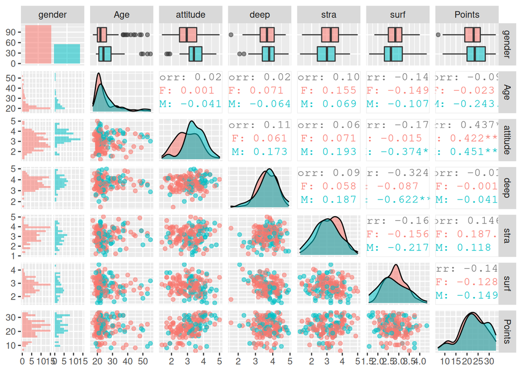

```r
p <- ggpairs(students2014, mapping = aes(col = gender, alpha = 0.4), lower = list(combo = wrap("facethist", bins = 20)))
# draw the plot
p
```

Then comes the actual regression modeling. Attitude, stra and surf were chosen as the explanatory variables as they showed the highest correlations to Points in the exploratory plots above.

```r
lm <- lm(Points ~ attitude + stra + surf, data = students2014)
```

Then we examine the model we made:

```r
summary(lm)
```

```
##
## Call:
## lm(formula = Points ~ attitude + stra + surf, data = students2014)
##
## Residuals:
##      Min       1Q   Median       3Q      Max
## -17.1550  -3.4346   0.5156   3.6401  10.8952
##
## Coefficients:
##             Estimate Std. Error t value Pr(>|t|)
## (Intercept)  11.0171     3.6837   2.991  0.00322 **
## attitude      3.3952     0.5741   5.913 1.93e-08 ***
## stra          0.8531     0.5416   1.575  0.11716
## surf         -0.5861     0.8014  -0.731  0.46563
## ---
## Signif. codes:  0 '***' 0.001 '**' 0.01 '*' 0.05 '.' 0.1 ' ' 1
##
## Residual standard error: 5.296 on 162 degrees of freedom
## Multiple R-squared:  0.2074, Adjusted R-squared:  0.1927
## F-statistic: 14.13 on 3 and 162 DF,  p-value: 3.156e-08
```

We see that the coefficients for stra and surf have high p-values, in other words not statistically significant, so lets remove them (this should give the most parsimonious model)

```r
lm <- lm(Points ~ attitude, data = students2014)
summary(lm)
```

```
##
## Call:
## lm(formula = Points ~ attitude, data = students2014)
##
## Residuals:
##      Min       1Q   Median       3Q      Max
## -16.9763  -3.2119   0.4339   4.1534  10.6645
##
## Coefficients:
##             Estimate Std. Error t value Pr(>|t|)
## (Intercept)  11.6372     1.8303   6.358 1.95e-09 ***
## attitude      3.5255     0.5674   6.214 4.12e-09 ***
## ---
## Signif. codes:  0 '***' 0.001 '**' 0.01 '*' 0.05 '.' 0.1 ' ' 1
##
## Residual standard error: 5.32 on 164 degrees of freedom
## Multiple R-squared:  0.1906, Adjusted R-squared:  0.1856
## F-statistic: 38.61 on 1 and 164 DF,  p-value: 4.119e-09
```

Then we generate some diagnostic plots to check if the model assumptions are correct. Calling plot() on a lm-object will call lm.plot(), meaning we can use the which option to select plot types. The par() function puts the plots in a nice grid.

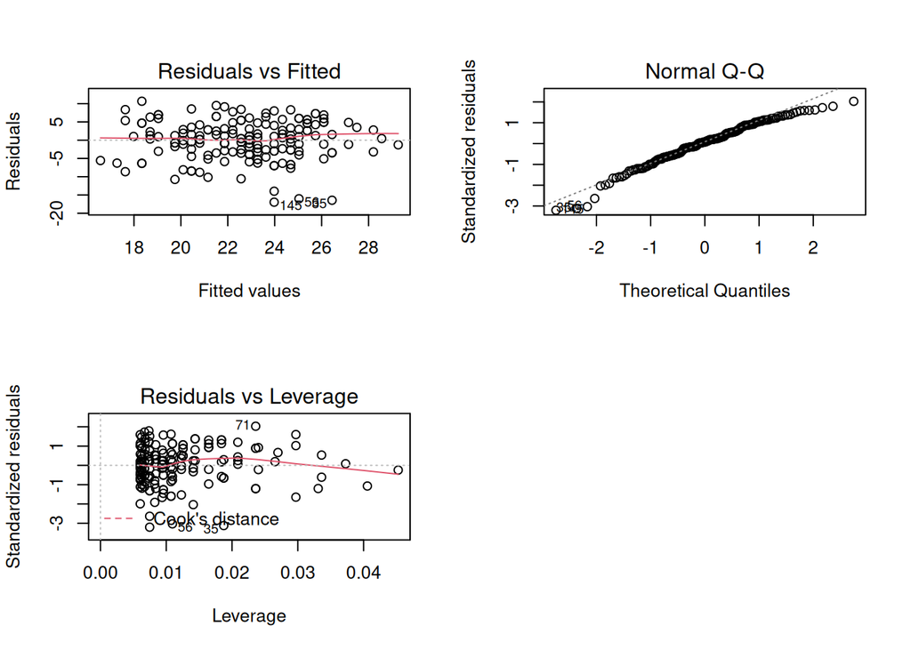

```r
par(mfrow = c(2,2))
plot(lm, which = c(1,2,5))
```